# Creativity Crime

# RQ1: How does an individual’s understanding of the legal system and moral judgments influence their sentencing decisions?

```r
dec <- lmer(sentence ~ legal + moral_valence + legal*moral_valence + (1 | PID), data = df_long)
summary(dec)
```

```
## Linear mixed model fit by REML. t-tests use Satterthwaite's method [
## lmerModLmerTest]
## Formula: sentence ~ legal + moral_valence + legal * moral_valence + (1 |
##     PID)
##    Data: df_long
##
## REML criterion at convergence: 11725.6
##
## Scaled residuals:
##     Min      1Q  Median      3Q     Max
## -3.4550 -0.5181  0.1243  0.6199  2.7909
##
## Random effects:
##  Groups   Name        Variance Std.Dev.
##  PID      (Intercept) 1.536    1.239
##  Residual             4.225    2.055
## Number of obs: 2599, groups:  PID, 650
##
## Fixed effects:
##                                      Estimate Std. Error         df t value
## (Intercept)                           9.31592    0.28519 2136.15816  32.665
## legal                                -0.14815    0.04607 2136.05873  -3.216
## moral_valencesinful                  -3.46862    0.34541 1943.23557 -10.042
## moral_valenceself_interested         -5.47352    0.34541 1943.23557 -15.847
## moral_valenceambiguous               -4.31128    0.34541 1943.23557 -12.482
## legal:moral_valencesinful             0.19745    0.05580 1943.21015   3.539
## legal:moral_valenceself_interested    0.26095    0.05580 1943.21015   4.677
## legal:moral_valenceambiguous          0.12524    0.05580 1943.21015   2.244
##                                                Pr(>|t|)
## (Intercept)                        < 0.0000000000000002 ***
## legal                                          0.001321 **
## moral_valencesinful                < 0.0000000000000002 ***
## moral_valenceself_interested       < 0.0000000000000002 ***
## moral_valenceambiguous             < 0.0000000000000002 ***
## legal:moral_valencesinful                      0.000412 ***
## legal:moral_valenceself_interested           0.00000312 ***
## legal:moral_valenceambiguous                   0.024917 *
## ---
## Signif. codes:  0 '***' 0.001 '**' 0.01 '*' 0.05 '.' 0.1 ' ' 1
##
## Correlation of Fixed Effects:
##               (Intr) legal  mrl_vlncs mrl_v_ mrl_vlncm lgl:mrl_vlncs lgl:__
## legal         -0.944
## mrl_vlncsnf   -0.606  0.572
## mrl_vlncsl_   -0.606  0.572  0.500
## mrl_vlncmbg   -0.606  0.572  0.500     0.500
## lgl:mrl_vlncs  0.572 -0.606 -0.944    -0.472 -0.472
## lgl:mrl_vl_    0.572 -0.606 -0.472    -0.944 -0.472     0.500
## lgl:mrl_vlncm  0.572 -0.606 -0.472    -0.472 -0.944     0.500         0.500
```

```r
standardize_parameters(dec, method = "refit")
```

```
## # Standardization method: refit
##
## Parameter                          | Std. Coef. |         95% CI
## ----------------------------------------------------------------
## (Intercept)                        |       0.86 | [ 0.80,  0.93]
## legal                              |      -0.11 | [-0.17, -0.04]
## moral_valencesinful                |      -0.81 | [-0.89, -0.73]
## moral_valenceself_interested       |      -1.38 | [-1.46, -1.30]
## moral_valenceambiguous             |      -1.25 | [-1.33, -1.17]
## legal:moral_valencesinful          |       0.14 | [ 0.06,  0.22]
## legal:moral_valenceself_interested |       0.19 | [ 0.11,  0.26]
## legal:moral_valenceambiguous       |       0.09 | [ 0.01,  0.17]
```

```r
r2(dec)
```

```
## # R2 for Mixed Models
##
##   Conditional R2: 0.484
##      Marginal R2: 0.296
```

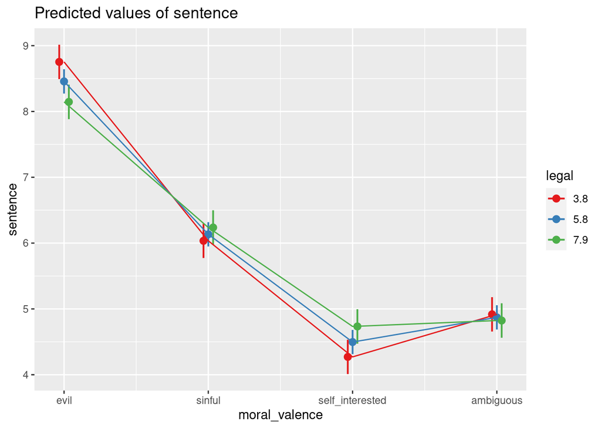

```r
plot_model(dec,
           type = "pred",
           terms = c("moral_valence", "legal")) +
  geom_line()
```

#RQ2: Will there be a cross-cultural difference in terms of severity, harmfulness and sentencing given to the different types of crime?

```r
cult_diff<- filter(df_long, country_origin < 3, stringsAsFactors = TRUE)


# Severity
sev_nation <- lmer(severity ~  age + gender + education + ses + country_origin + psych_total + mach_total + narc_total + sadism_total  + mfq_individualizing + mfq_bind + cse_total + legal + creativity + moral_valence + creativity*moral_valence + (1 | PID), data = cult_diff)
summary(sev_nation)
```

```
## Linear mixed model fit by REML. t-tests use Satterthwaite's method [
## lmerModLmerTest]
## Formula: severity ~ age + gender + education + ses + country_origin +
##     psych_total + mach_total + narc_total + sadism_total + mfq_individualizing +
##     mfq_bind + cse_total + legal + creativity + moral_valence +
##     creativity * moral_valence + (1 | PID)
##    Data: cult_diff
##
## REML criterion at convergence: 10502.7
##
## Scaled residuals:
##     Min      1Q  Median      3Q     Max
## -3.4480 -0.5277  0.1094  0.6597  3.0080
##
## Random effects:
##  Groups   Name        Variance Std.Dev.
##  PID      (Intercept) 0.9185   0.9584
##  Residual             3.4892   1.8679
## Number of obs: 2443, groups:  PID, 613
##
## Fixed effects:
##                                                       Estimate  Std. Error
## (Intercept)                                           6.954433    0.700874
## age                                                   0.003592    0.008456
## gender2                                              -0.265382    0.118562
## education                                             0.007470    0.076194
## ses                                                   0.019858    0.034800
## country_origin                                       -0.108169    0.190643
## psych_total                                          -0.027924    0.014601
## mach_total                                           -0.016292    0.014748
## narc_total                                            0.022681    0.014740
## sadism_total                                         -0.012857    0.013772
## mfq_individualizing                                   0.011361    0.007537
## mfq_bind                                              0.026503    0.004967
## cse_total                                             0.006555    0.012135
## legal                                                 0.142739    0.030358
## creativityNonCreative                                -0.213523    0.162513
## moral_valencesinful                                  -1.727130    0.158373
## moral_valenceself_interested                         -3.025533    0.159999
## moral_valenceambiguous                               -2.449793    0.157291
```

[output cut: 34 more lines]

```
## narc_total                                                      0.12440
## sadism_total                                                    0.35089
## mfq_individualizing                                             0.13224
## mfq_bind                                                    0.000000135 ***
## cse_total                                                       0.58926
## legal                                                       0.000003202 ***
## creativityNonCreative                                           0.18902
## moral_valencesinful                                < 0.0000000000000002 ***
## moral_valenceself_interested                       < 0.0000000000000002 ***
## moral_valenceambiguous                             < 0.0000000000000002 ***
## creativityNonCreative:moral_valencesinful                       0.98110
## creativityNonCreative:moral_valenceself_interested              0.03296 *
## creativityNonCreative:moral_valenceambiguous                    0.00217 **
## ---
## Signif. codes:  0 '***' 0.001 '**' 0.01 '*' 0.05 '.' 0.1 ' ' 1
```

```
##
## Correlation matrix not shown by default, as p = 21 > 12.
## Use print(x, correlation=TRUE)  or
##     vcov(x)        if you need it
```

```r
standardize_parameters(sev_nation, method = "refit")
```

```
## # Standardization method: refit
##
## Parameter                                          | Std. Coef. |         95% CI
## --------------------------------------------------------------------------------
## (Intercept)                                        |       0.87 | [ 0.77,  0.98]
## age                                                |       0.01 | [-0.04,  0.07]
## gender2                                            |      -0.10 | [-0.20, -0.01]
## education                                          |   3.67e-03 | [-0.07,  0.08]
## ses                                                |       0.01 | [-0.03,  0.06]
## country_origin                                     |      -0.02 | [-0.09,  0.05]
## psych_total                                        |      -0.07 | [-0.13,  0.00]
## mach_total                                         |      -0.03 | [-0.08,  0.02]
## narc_total                                         |       0.05 | [-0.01,  0.10]
## sadism_total                                       |      -0.03 | [-0.09,  0.03]
## mfq_individualizing                                |       0.04 | [-0.01,  0.10]
## mfq_bind                                           |       0.15 | [ 0.09,  0.20]
## cse_total                                          |       0.01 | [-0.03,  0.06]
## legal                                              |       0.12 | [ 0.07,  0.16]
## creativityNonCreative                              |      -0.08 | [-0.21,  0.04]
## moral_valencesinful                                |      -0.68 | [-0.81, -0.56]
## moral_valenceself_interested                       |      -1.20 | [-1.32, -1.07]
## moral_valenceambiguous                             |      -0.97 | [-1.09, -0.85]
## creativityNonCreative:moral_valencesinful          |  -2.20e-03 | [-0.18,  0.18]
## creativityNonCreative:moral_valenceself_interested |      -0.20 | [-0.38, -0.02]
## creativityNonCreative:moral_valenceambiguous       |      -0.28 | [-0.47, -0.10]
```

```r
r2(sev_nation)
```

```
## # R2 for Mixed Models
##
##   Conditional R2: 0.459
##      Marginal R2: 0.317
```

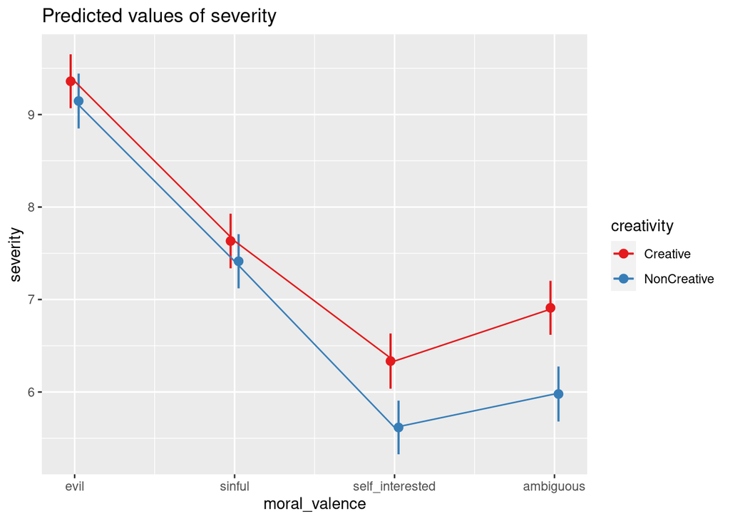

```r
plot_model(sev_nation,
           type = "pred",
           terms = c("moral_valence", "creativity")) +
  geom_line()
```

```r
# Harmfulness
harm_nation <- lmer(harm ~ age + gender + education + ses +  country_origin + psych_total + mach_total + narc_total + sadism_total  + mfq_individualizing + mfq_bind + cse_total + legal + creativity + moral_valence + creativity*moral_valence + (1 | PID), data = cult_diff)
summary(harm_nation)
```

```
## Linear mixed model fit by REML. t-tests use Satterthwaite's method [
## lmerModLmerTest]
## Formula:
## harm ~ age + gender + education + ses + country_origin + psych_total +
##     mach_total + narc_total + sadism_total + mfq_individualizing +
##     mfq_bind + cse_total + legal + creativity + moral_valence +
##     creativity * moral_valence + (1 | PID)
##    Data: cult_diff
##
## REML criterion at convergence: 10831.4
##
## Scaled residuals:
##     Min      1Q  Median      3Q     Max
## -3.5139 -0.5882  0.1184  0.6340  2.6972
##
## Random effects:
##  Groups   Name        Variance Std.Dev.
##  PID      (Intercept) 0.8491   0.9214
##  Residual             4.0639   2.0159
## Number of obs: 2449, groups:  PID, 613
##
## Fixed effects:
##                                                        Estimate   Std. Error
## (Intercept)                                           7.1927644    0.7142622
## age                                                   0.0140655    0.0086088
## gender2                                              -0.3589212    0.1208584
## education                                             0.0105426    0.0777527
## ses                                                   0.0842678    0.0354858
## country_origin                                       -0.3912286    0.1944591
## psych_total                                          -0.0153145    0.0148844
## mach_total                                           -0.0342911    0.0150339
## narc_total                                            0.0388462    0.0150462
## sadism_total                                         -0.0118050    0.0140524
## mfq_individualizing                                   0.0148853    0.0076728
## mfq_bind                                              0.0161595    0.0050561
## cse_total                                            -0.0004271    0.0123666
## legal                                                 0.1468829    0.0309687
## creativityNonCreative                                -0.0245602    0.1736765
## moral_valencesinful                                  -2.1388865    0.1697217
## moral_valenceself_interested                         -3.9690583    0.1713864
```

[output cut: 35 more lines]

```
## narc_total                                                     0.010065 *
## sadism_total                                                   0.401206
## mfq_individualizing                                            0.052849 .
## mfq_bind                                                       0.001467 **
## cse_total                                                      0.972459
## legal                                                        0.00000264 ***
## creativityNonCreative                                          0.887555
## moral_valencesinful                                < 0.0000000000000002 ***
## moral_valenceself_interested                       < 0.0000000000000002 ***
## moral_valenceambiguous                             < 0.0000000000000002 ***
## creativityNonCreative:moral_valencesinful                      0.787255
## creativityNonCreative:moral_valenceself_interested             0.021182 *
## creativityNonCreative:moral_valenceambiguous                   0.000124 ***
## ---
## Signif. codes:  0 '***' 0.001 '**' 0.01 '*' 0.05 '.' 0.1 ' ' 1
```

```
##
## Correlation matrix not shown by default, as p = 21 > 12.
## Use print(x, correlation=TRUE)  or
##     vcov(x)        if you need it
```

```r
standardize_parameters(harm_nation, method = "refit")
```

```
## # Standardization method: refit
##
## Parameter                                          | Std. Coef. |         95% CI
## --------------------------------------------------------------------------------
## (Intercept)                                        |       0.97 | [ 0.88,  1.07]
## age                                                |       0.04 | [-0.01,  0.09]
## gender2                                            |      -0.12 | [-0.21, -0.04]
## education                                          |   4.56e-03 | [-0.06,  0.07]
## ses                                                |       0.05 | [ 0.01,  0.09]
## country_origin                                     |      -0.07 | [-0.13,  0.00]
## psych_total                                        |      -0.03 | [-0.09,  0.03]
## mach_total                                         |      -0.06 | [-0.10, -0.01]
## narc_total                                         |       0.07 | [ 0.02,  0.12]
## sadism_total                                       |      -0.02 | [-0.08,  0.03]
## mfq_individualizing                                |       0.05 | [ 0.00,  0.10]
## mfq_bind                                           |       0.08 | [ 0.03,  0.13]
## cse_total                                          |  -7.41e-04 | [-0.04,  0.04]
## legal                                              |       0.10 | [ 0.06,  0.15]
## creativityNonCreative                              |  -8.55e-03 | [-0.13,  0.11]
## moral_valencesinful                                |      -0.74 | [-0.86, -0.63]
## moral_valenceself_interested                       |      -1.38 | [-1.50, -1.26]
## moral_valenceambiguous                             |      -1.18 | [-1.30, -1.07]
## creativityNonCreative:moral_valencesinful          |      -0.02 | [-0.19,  0.15]
## creativityNonCreative:moral_valenceself_interested |      -0.20 | [-0.37, -0.03]
## creativityNonCreative:moral_valenceambiguous       |      -0.33 | [-0.50, -0.16]
```

```r
r2(harm_nation)
```

```
## # R2 for Mixed Models
##
##   Conditional R2: 0.511
##      Marginal R2: 0.408
```

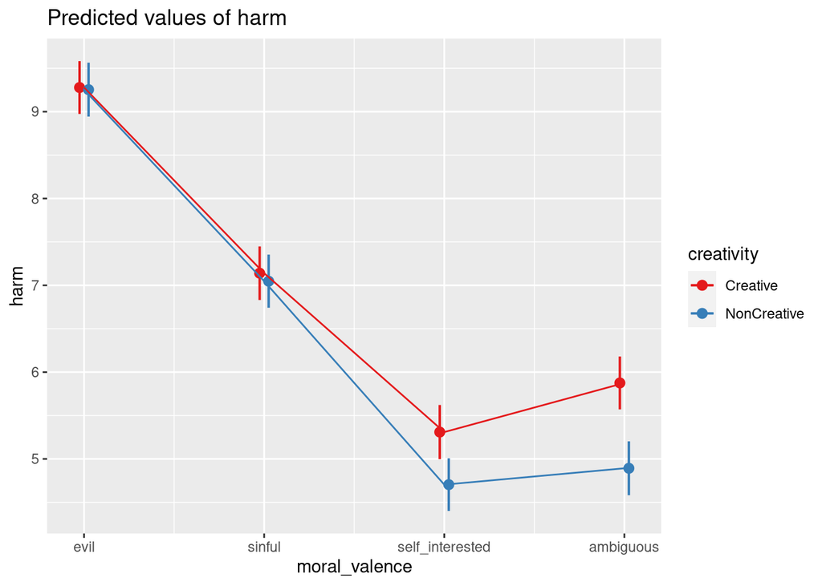

```r
plot_model(harm_nation,
           type = "pred",
           terms = c("moral_valence", "creativity")) +
  geom_line()
```

```r
# Sentencing
sentence_nation <- lmer(sentence ~ age + gender + education + ses + country_origin + psych_total + mach_total + narc_total + sadism_total  + mfq_individualizing + mfq_bind + cse_total + legal + creativity + moral_valence + creativity*moral_valence + (1 | PID), data = cult_diff)
summary(sentence_nation)
```

```
## Linear mixed model fit by REML. t-tests use Satterthwaite's method [
## lmerModLmerTest]
## Formula: sentence ~ age + gender + education + ses + country_origin +
##     psych_total + mach_total + narc_total + sadism_total + mfq_individualizing +
##     mfq_bind + cse_total + legal + creativity + moral_valence +
##     creativity * moral_valence + (1 | PID)
##    Data: cult_diff
##
## REML criterion at convergence: 11063.9
##
## Scaled residuals:
##     Min      1Q  Median      3Q     Max
## -3.6145 -0.5197  0.1299  0.6264  2.9535
##
## Random effects:
##  Groups   Name        Variance Std.Dev.
##  PID      (Intercept) 1.373    1.172
##  Residual             4.205    2.051
## Number of obs: 2452, groups:  PID, 613
##
## Fixed effects:
##                                                       Estimate  Std. Error
## (Intercept)                                           6.817354    0.811695
## age                                                   0.010344    0.009811
## gender2                                              -0.504048    0.137729
## education                                             0.011705    0.088632
## ses                                                  -0.037410    0.040437
## country_origin                                        0.167926    0.221640
## psych_total                                          -0.060904    0.016962
## mach_total                                            0.036118    0.017132
## narc_total                                           -0.020335    0.017137
## sadism_total                                          0.013753    0.016014
## mfq_individualizing                                   0.017364    0.008744
## mfq_bind                                              0.007749    0.005760
## cse_total                                             0.017872    0.014027
## legal                                                 0.044995    0.035290
## creativityNonCreative                                 0.001298    0.179752
## moral_valencesinful                                  -2.363427    0.174745
## moral_valenceself_interested                         -3.493880    0.176459
## moral_valenceambiguous                               -3.229371    0.173292
```

[output cut: 34 more lines]

```
## narc_total                                                     0.235853
## sadism_total                                                   0.390806
## mfq_individualizing                                            0.047503 *
## mfq_bind                                                       0.179034
## cse_total                                                      0.203120
## legal                                                          0.202805
## creativityNonCreative                                          0.994239
## moral_valencesinful                                < 0.0000000000000002 ***
## moral_valenceself_interested                       < 0.0000000000000002 ***
## moral_valenceambiguous                             < 0.0000000000000002 ***
## creativityNonCreative:moral_valencesinful                      0.567303
## creativityNonCreative:moral_valenceself_interested             0.003990 **
## creativityNonCreative:moral_valenceambiguous                   0.019699 *
## ---
## Signif. codes:  0 '***' 0.001 '**' 0.01 '*' 0.05 '.' 0.1 ' ' 1
```

```
##
## Correlation matrix not shown by default, as p = 21 > 12.
## Use print(x, correlation=TRUE)  or
##     vcov(x)        if you need it
```

```r
standardize_parameters(sentence_nation, method = "refit")
```

```
## # Standardization method: refit
##
## Parameter                                          | Std. Coef. |         95% CI
## --------------------------------------------------------------------------------
## (Intercept)                                        |       0.95 | [ 0.85,  1.05]
## age                                                |       0.03 | [-0.03,  0.09]
## gender2                                            |      -0.18 | [-0.27, -0.08]
## education                                          |   5.10e-03 | [-0.07,  0.08]
## ses                                                |      -0.02 | [-0.07,  0.02]
## country_origin                                     |       0.03 | [-0.05,  0.11]
## psych_total                                        |      -0.13 | [-0.20, -0.06]
## mach_total                                         |       0.06 | [ 0.00,  0.11]
## narc_total                                         |      -0.04 | [-0.10,  0.02]
## sadism_total                                       |       0.03 | [-0.04,  0.09]
## mfq_individualizing                                |       0.06 | [ 0.00,  0.11]
## mfq_bind                                           |       0.04 | [-0.02,  0.09]
## cse_total                                          |       0.03 | [-0.02,  0.08]
## legal                                              |       0.03 | [-0.02,  0.08]
## creativityNonCreative                              |   4.55e-04 | [-0.12,  0.12]
## moral_valencesinful                                |      -0.83 | [-0.95, -0.71]
## moral_valenceself_interested                       |      -1.23 | [-1.35, -1.10]
## moral_valenceambiguous                             |      -1.13 | [-1.25, -1.01]
## creativityNonCreative:moral_valencesinful          |       0.05 | [-0.13,  0.23]
## creativityNonCreative:moral_valenceself_interested |      -0.27 | [-0.45, -0.08]
## creativityNonCreative:moral_valenceambiguous       |      -0.21 | [-0.39, -0.03]
```

```r
r2(sentence_nation)
```

```
## # R2 for Mixed Models
##
##   Conditional R2: 0.486
##      Marginal R2: 0.319
```

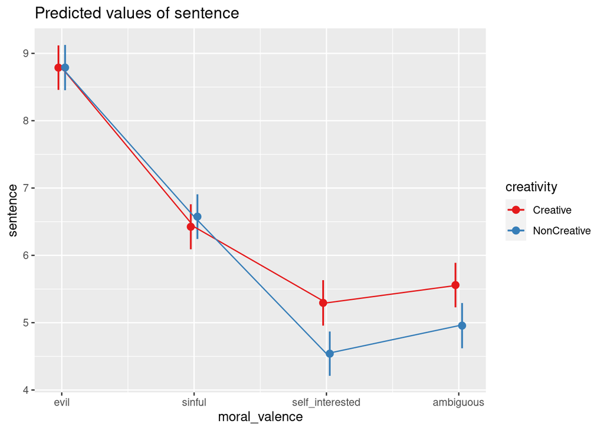

```r
plot_model(sentence_nation,
           type = "pred",
           terms = c("moral_valence", "creativity")) +
  geom_line()
```

```r
# Rehabilitation
rehab_nation <- lmer(rehab ~ age + gender + education + ses +  country_origin + psych_total + mach_total + narc_total + sadism_total  + mfq_individualizing + mfq_bind + cse_total + legal + creativity + moral_valence + creativity*moral_valence + (1 | PID), data = cult_diff)
summary(rehab_nation)
```

```
## Linear mixed model fit by REML. t-tests use Satterthwaite's method [
## lmerModLmerTest]
## Formula:
## rehab ~ age + gender + education + ses + country_origin + psych_total +
##     mach_total + narc_total + sadism_total + mfq_individualizing +
##     mfq_bind + cse_total + legal + creativity + moral_valence +
##     creativity * moral_valence + (1 | PID)
##    Data: cult_diff
##
## REML criterion at convergence: 11990.4
##
## Scaled residuals:
##      Min       1Q   Median       3Q      Max
## -2.94579 -0.69336 -0.03103  0.64051  2.74417
##
## Random effects:
##  Groups   Name        Variance Std.Dev.
##  PID      (Intercept) 1.563    1.250
##  Residual             6.407    2.531
## Number of obs: 2451, groups:  PID, 613
##
## Fixed effects:
##                                                       Estimate  Std. Error
## (Intercept)                                           3.166961    0.929103
## age                                                  -0.002185    0.011211
## gender2                                              -0.185167    0.157407
## education                                             0.217138    0.101277
## ses                                                   0.087125    0.046224
## country_origin                                        0.020555    0.253267
## psych_total                                           0.015553    0.019385
## mach_total                                           -0.027807    0.019579
## narc_total                                            0.006313    0.019583
## sadism_total                                         -0.015183    0.018303
## mfq_individualizing                                   0.017634    0.009993
## mfq_bind                                              0.010627    0.006582
## cse_total                                             0.009562    0.016042
## legal                                                 0.056341    0.040330
## creativityNonCreative                                 0.271087    0.219365
## moral_valencesinful                                  -0.923412    0.213986
## moral_valenceself_interested                         -2.206106    0.215972
```

[output cut: 35 more lines]

```
## narc_total                                                     0.747308
## sadism_total                                                   0.407116
## mfq_individualizing                                            0.078131 .
## mfq_bind                                                       0.106934
## cse_total                                                      0.551345
## legal                                                          0.162938
## creativityNonCreative                                          0.216665
## moral_valencesinful                                   0.000016642665462 ***
## moral_valenceself_interested                       < 0.0000000000000002 ***
## moral_valenceambiguous                                0.000000000000246 ***
## creativityNonCreative:moral_valencesinful                      0.086278 .
## creativityNonCreative:moral_valenceself_interested             0.020729 *
## creativityNonCreative:moral_valenceambiguous                   0.043225 *
## ---
## Signif. codes:  0 '***' 0.001 '**' 0.01 '*' 0.05 '.' 0.1 ' ' 1
```

```
##
## Correlation matrix not shown by default, as p = 21 > 12.
## Use print(x, correlation=TRUE)  or
##     vcov(x)        if you need it
```

```r
standardize_parameters(rehab_nation, method = "refit")
```

```
## # Standardization method: refit
##
## Parameter                                          | Std. Coef. |         95% CI
## --------------------------------------------------------------------------------
## (Intercept)                                        |       0.46 | [ 0.34,  0.58]
## age                                                |  -6.25e-03 | [-0.07,  0.06]
## gender2                                            |      -0.06 | [-0.16,  0.04]
## education                                          |       0.09 | [ 0.01,  0.17]
## ses                                                |       0.05 | [ 0.00,  0.10]
## country_origin                                     |   3.40e-03 | [-0.08,  0.09]
## psych_total                                        |       0.03 | [-0.04,  0.11]
## mach_total                                         |      -0.04 | [-0.10,  0.02]
## narc_total                                         |       0.01 | [-0.05,  0.08]
## sadism_total                                       |      -0.03 | [-0.10,  0.04]
## mfq_individualizing                                |       0.05 | [-0.01,  0.12]
## mfq_bind                                           |       0.05 | [-0.01,  0.11]
## cse_total                                          |       0.02 | [-0.04,  0.07]
## legal                                              |       0.04 | [-0.02,  0.09]
## creativityNonCreative                              |       0.09 | [-0.05,  0.23]
## moral_valencesinful                                |      -0.31 | [-0.45, -0.17]
## moral_valenceself_interested                       |      -0.73 | [-0.87, -0.59]
## moral_valenceambiguous                             |      -0.52 | [-0.66, -0.38]
## creativityNonCreative:moral_valencesinful          |      -0.18 | [-0.39,  0.03]
## creativityNonCreative:moral_valenceself_interested |      -0.24 | [-0.45, -0.04]
## creativityNonCreative:moral_valenceambiguous       |      -0.21 | [-0.42, -0.01]
```

```r
r2(rehab_nation)
```

```
## # R2 for Mixed Models
##
##   Conditional R2: 0.300
##      Marginal R2: 0.130
```

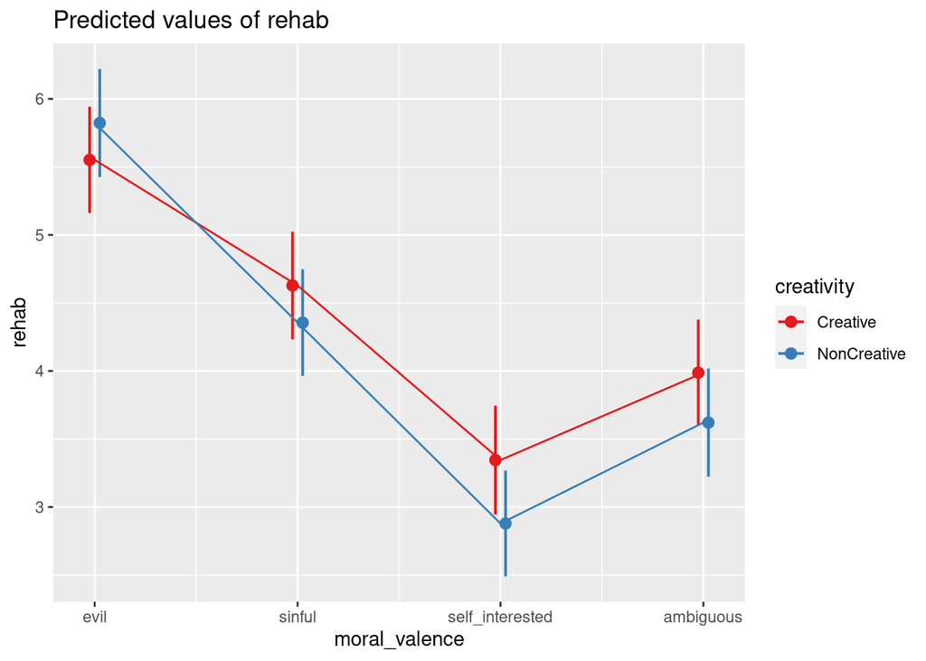

```r
plot_model(rehab_nation,
           type = "pred",
           terms = c("moral_valence", "creativity")) +
  geom_line()
```

# RQ3: What are the distinct profiles of participants who consider crimes as more harmful, severe, deserving of higher sentencing, and lower rehabilitation recommendations?

```r
library(tidyverse)
library(cluster)
library(hopkins)
library(factoextra)
library(NbClust)
library(fpc)

cluster_vars <- crCrime %>%
  transmute(
    mean_severity = rowMeans(select(., ends_with("serious")), na.rm = TRUE),
    mean_harm     = rowMeans(select(., ends_with("harm")), na.rm = TRUE),
    mean_sentence = rowMeans(select(., ends_with("sentence")), na.rm = TRUE),
    mean_rehab    = rowMeans(select(., ends_with("rehab")), na.rm = TRUE)
  )


scaled_cluster <- scale(cluster_vars)

#checking clusterability

set.seed(123)

hopkins_result <- hopkins(scaled_cluster)
hopkins_result
```

```
## [1] 0.9947593
```

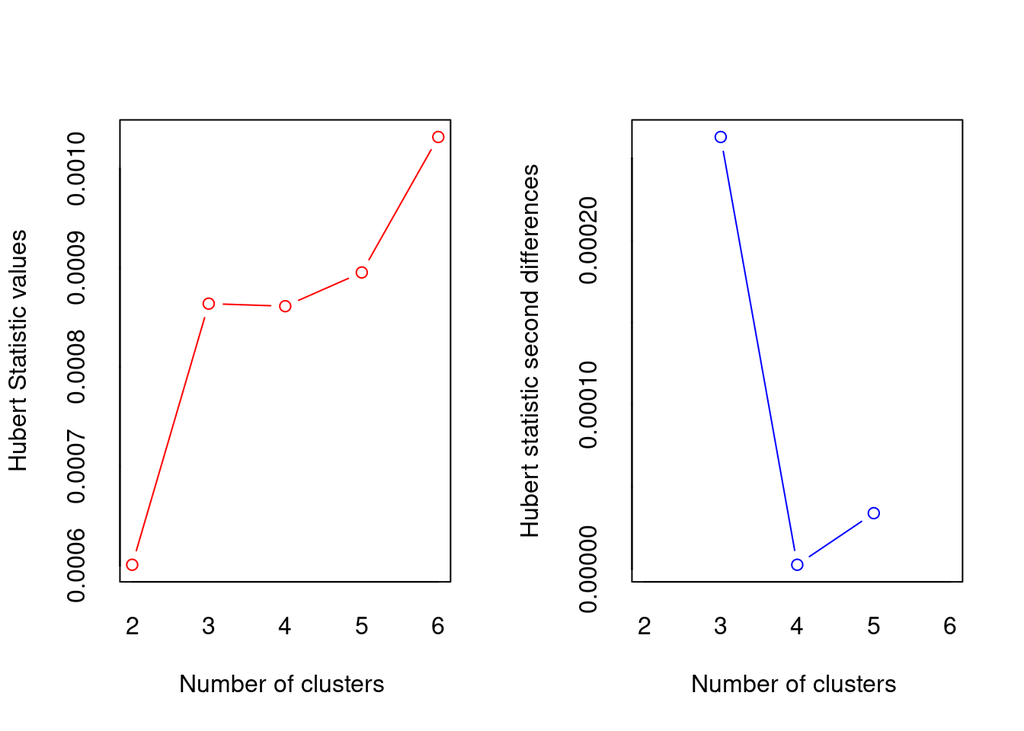

```
## *** : The Hubert index is a graphical method of determining the number of clusters.
##                 In the plot of Hubert index, we seek a significant knee that corresponds to a
##                 significant increase of the value of the measure i.e the significant peak in Hubert
##                 index second differences plot.
##
```

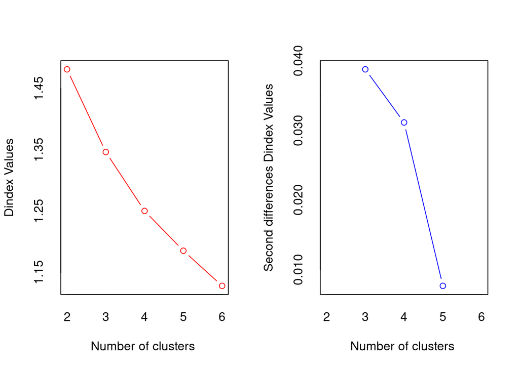

```
## *** : The D index is a graphical method of determining the number of clusters.
##                 In the plot of D index, we seek a significant knee (the significant peak in Dindex
##                 second differences plot) that corresponds to a significant increase of the value of
##                 the measure.
##
## * Among all indices:
## * 10 proposed 2 as the best number of clusters
## * 7 proposed 3 as the best number of clusters
## * 3 proposed 4 as the best number of clusters
## * 2 proposed 5 as the best number of clusters
## * 1 proposed 6 as the best number of clusters
##
##                    ***** Conclusion *****
##
## * According to the majority rule, the best number of clusters is  2
##
##
```

```r
nb_result <- NbClust(
  scaled_cluster,
  distance = "euclidean",
  min.nc = 2,
  max.nc = 6,
  method = "kmeans"
)
```

```r
# K-means clustering (k = 2)

set.seed(123)

km <- kmeans(
  scaled_cluster,
  centers = 2,
  nstart = 50
)

cluster_vars$Cluster <- factor(km$cluster)

# Attach cluster membership to participant data
cluster_profiles <- crCrime %>%
  mutate(Cluster = factor(km$cluster))

#  Cluster evaluation

# Cluster sizes
table(cluster_vars$Cluster)
```

```
##
##   1   2
## 300 352
```

```r
# Cluster centers
km$centers
```

```
##   mean_severity  mean_harm mean_sentence mean_rehab
## 1    -0.7686199 -0.7569952    -0.4620656 -0.5238444
## 2     0.6550737  0.6451664     0.3938059  0.4464583
```

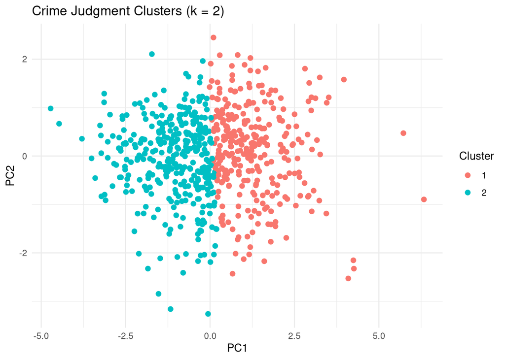

```r
# PCA visualization
pca <- prcomp(scaled_cluster)

pca_df <- data.frame(
  PC1 = pca$x[,1],
  PC2 = pca$x[,2],
  Cluster = cluster_vars$Cluster
)

ggplot(
  pca_df,
  aes(PC1, PC2, color = Cluster)
) +
  geom_point(size = 2) +
  theme_minimal() +
  labs(
    title = "Crime Judgment Clusters (k = 2)"
  )
```

```
##   cluster size ave.sil.width
## 1       1  300          0.26
## 2       2  352          0.32
```

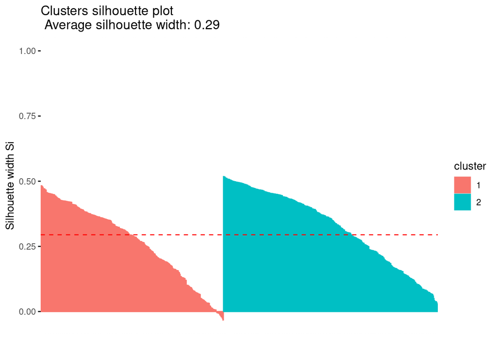

```r
# Silhouette plot
sil <- silhouette(
  km$cluster,
  dist(scaled_cluster)
)

fviz_silhouette(sil)
```

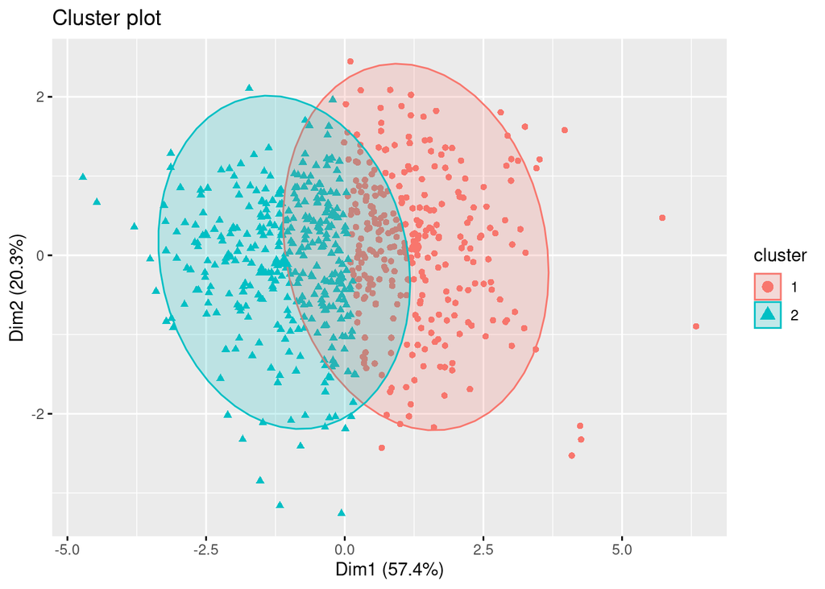

```r
# Cluster visualization
fviz_cluster(
  km,
  data = scaled_cluster,
  ellipse.type = "norm",
  geom = "point"
)
```

```r
# Interpret crime judgment clusters

cluster_summary <- cluster_vars %>%
  group_by(Cluster) %>%
  summarise(
    Severity = mean(mean_severity),
    Harm = mean(mean_harm),
    Sentence = mean(mean_sentence),
    Rehab = mean(mean_rehab),
    n = n(),
    .groups = "drop"
  )

cluster_summary
```

```
## # A tibble: 2 × 6
##   Cluster Severity  Harm Sentence Rehab     n
##   <fct>      <dbl> <dbl>    <dbl> <dbl> <int>
## 1 1           6.00  5.44     5.24  3.32   300
## 2 2           8.07  7.58     6.62  5.10   352
```

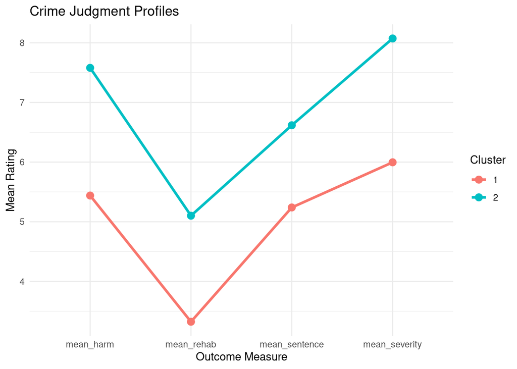

```r
# Profile plot
cluster_plot <- cluster_vars %>%
  pivot_longer(
    cols = mean_severity:mean_rehab,
    names_to = "Outcome",
    values_to = "Value"
  ) %>%
  group_by(Cluster, Outcome) %>%
  summarise(
    Value = mean(Value),
    .groups = "drop"
  )

ggplot(
  cluster_plot,
  aes(
    x = Outcome,
    y = Value,
    group = Cluster,
    color = Cluster
  )
) +
  geom_line(linewidth = 1.2) +
  geom_point(size = 3) +
  theme_minimal() +
  labs(
    title = "Crime Judgment Profiles",
    x = "Outcome Measure",
    y = "Mean Rating"
  )
```

```r
library(fpc)

# Dunn Index

stats_k2 <- cluster.stats(
  d = dist(scaled_cluster),
  clustering = km$cluster
)

stats_k2$dunn
```

```
## [1] 0.03292544
```

```r
# Statistical validation of cluster differences

manova_cluster <- manova(
  cbind(
    mean_severity,
    mean_harm,
    mean_sentence,
    mean_rehab
  ) ~ Cluster,
  data = cluster_vars
)

summary(manova_cluster)
```

```
##            Df  Pillai approx F num Df den Df                Pr(>F)
## Cluster     1 0.62321   267.53      4    647 < 0.00000000000000022 ***
## Residuals 650
## ---
## Signif. codes:  0 '***' 0.001 '**' 0.01 '*' 0.05 '.' 0.1 ' ' 1
```

```r
summary.aov(manova_cluster)
```

```
##  Response mean_severity :
##              Df Sum Sq Mean Sq F value                Pr(>F)
## Cluster       1 698.35  698.35  661.21 < 0.00000000000000022 ***
## Residuals   650 686.51    1.06
## ---
## Signif. codes:  0 '***' 0.001 '**' 0.01 '*' 0.05 '.' 0.1 ' ' 1
##
##  Response mean_harm :
##              Df Sum Sq Mean Sq F value                Pr(>F)
## Cluster       1 742.62  742.62  622.36 < 0.00000000000000022 ***
## Residuals   650 775.60    1.19
## ---
## Signif. codes:  0 '***' 0.001 '**' 0.01 '*' 0.05 '.' 0.1 ' ' 1
##
##  Response mean_sentence :
##              Df  Sum Sq Mean Sq F value                Pr(>F)
## Cluster       1  307.63 307.628  144.86 < 0.00000000000000022 ***
## Residuals   650 1380.37   2.124
## ---
## Signif. codes:  0 '***' 0.001 '**' 0.01 '*' 0.05 '.' 0.1 ' ' 1
##
##  Response mean_rehab :
##              Df  Sum Sq Mean Sq F value                Pr(>F)
## Cluster       1  512.14  512.14  198.82 < 0.00000000000000022 ***
## Residuals   650 1674.32    2.58
## ---
## Signif. codes:  0 '***' 0.001 '**' 0.01 '*' 0.05 '.' 0.1 ' ' 1
```

```r
# Psychological profiling of clusters

profile_summary <- cluster_profiles %>%
  group_by(Cluster) %>%
  summarise(
    psych = mean(psych_total, na.rm = TRUE),
    mach = mean(mach_total, na.rm = TRUE),
    narc = mean(narc_total, na.rm = TRUE),
    sadism = mean(sadism_total, na.rm = TRUE),

    individualizing = mean(mfq_individualizing, na.rm = TRUE),
    binding = mean(mfq_bind, na.rm = TRUE),

    legal = mean(legal, na.rm = TRUE),
    cse = mean(cse_total, na.rm = TRUE),

    .groups = "drop"
  )

profile_summary
```

```
## # A tibble: 2 × 9
##   Cluster psych  mach  narc sadism individualizing binding legal   cse
##   <fct>   <dbl> <dbl> <dbl>  <dbl>           <dbl>   <dbl> <dbl> <dbl>
## 1 1        15.8  23.9  21.1   18.6            41.0    50.8  5.41  23.8
## 2 2        15.9  24.4  22.2   18.3            43.7    56.3  6.21  24.7
```

```r
# MANOVA

manova_profiles <- manova(
  cbind(
    psych_total,
    mach_total,
    narc_total,
    sadism_total,
    mfq_individualizing,
    mfq_bind,
    legal,
    cse_total
  ) ~ Cluster,
  data = cluster_profiles
)

summary(manova_profiles)
```

```
##            Df   Pillai approx F num Df den Df         Pr(>F)
## Cluster     1 0.081312   7.0918      8    641 0.000000005245 ***
## Residuals 648
## ---
## Signif. codes:  0 '***' 0.001 '**' 0.01 '*' 0.05 '.' 0.1 ' ' 1
```

```r
summary.aov(manova_profiles)
```

```
##  Response psych_total :
##              Df  Sum Sq Mean Sq F value Pr(>F)
## Cluster       1     6.6   6.554  0.1821 0.6697
## Residuals   648 23326.7  35.998
##
##  Response mach_total :
##              Df  Sum Sq Mean Sq F value Pr(>F)
## Cluster       1    57.5  57.509  2.6274 0.1055
## Residuals   648 14183.7  21.888
##
##  Response narc_total :
##              Df  Sum Sq Mean Sq F value   Pr(>F)
## Cluster       1   215.9 215.941  8.3971 0.003885 **
## Residuals   648 16664.1  25.716
## ---
## Signif. codes:  0 '***' 0.001 '**' 0.01 '*' 0.05 '.' 0.1 ' ' 1
##
##  Response sadism_total :
##              Df Sum Sq Mean Sq F value Pr(>F)
## Cluster       1     11  11.000  0.3221 0.5706
## Residuals   648  22134  34.157
##
##  Response mfq_individualizing :
##              Df Sum Sq Mean Sq F value    Pr(>F)
## Cluster       1   1220 1220.37  14.351 0.0001658 ***
## Residuals   648  55102   85.03
## ---
## Signif. codes:  0 '***' 0.001 '**' 0.01 '*' 0.05 '.' 0.1 ' ' 1
##
##  Response mfq_bind :
##              Df Sum Sq Mean Sq F value       Pr(>F)
## Cluster       1   5233  5233.5  28.101 0.0000001581 ***
## Residuals   648 120681   186.2
## ---
## Signif. codes:  0 '***' 0.001 '**' 0.01 '*' 0.05 '.' 0.1 ' ' 1
##
##  Response legal :
##              Df  Sum Sq Mean Sq F value       Pr(>F)
## Cluster       1  102.89 102.893  25.535 0.0000005658 ***
## Residuals   648 2611.10   4.029
## ---
## Signif. codes:  0 '***' 0.001 '**' 0.01 '*' 0.05 '.' 0.1 ' ' 1
##
##  Response cse_total :
##              Df  Sum Sq Mean Sq F value Pr(>F)
## Cluster       1   163.1 163.081  6.4392 0.0114 *
## Residuals   648 16411.4  25.326
## ---
## Signif. codes:  0 '***' 0.001 '**' 0.01 '*' 0.05 '.' 0.1 ' ' 1
##
## 2 observations deleted due to missingness
```

```r
# t-tests

t.test(psych_total ~ Cluster, data = cluster_profiles)
```

```
##
##  Welch Two Sample t-test
##
## data:  psych_total by Cluster
## t = -0.32584, df = 646.29, p-value = 0.7447
## alternative hypothesis: true difference in means between group 1 and group 2 is not equal to 0
## 95 percent confidence interval:
##  -1.0763300  0.7699664
## sample estimates:
## mean in group 1 mean in group 2
##        15.79000        15.94318
```

```r
t.test(mach_total ~ Cluster, data = cluster_profiles)
```

```
##
##  Welch Two Sample t-test
##
## data:  mach_total by Cluster
## t = -1.3959, df = 635.11, p-value = 0.1632
## alternative hypothesis: true difference in means between group 1 and group 2 is not equal to 0
## 95 percent confidence interval:
##  -1.2582702  0.2126641
## sample estimates:
## mean in group 1 mean in group 2
##        23.90333        24.42614
```

```r
t.test(narc_total ~ Cluster, data = cluster_profiles)
```

```
##
##  Welch Two Sample t-test
##
## data:  narc_total by Cluster
## t = -2.6793, df = 649.98, p-value = 0.007564
## alternative hypothesis: true difference in means between group 1 and group 2 is not equal to 0
## 95 percent confidence interval:
##  -1.853458 -0.285709
## sample estimates:
## mean in group 1 mean in group 2
##        21.08667        22.15625
```

```r
t.test(sadism_total ~ Cluster, data = cluster_profiles)
```

```
##
##  Welch Two Sample t-test
##
## data:  sadism_total by Cluster
## t = 0.70292, df = 645.69, p-value = 0.4824
## alternative hypothesis: true difference in means between group 1 and group 2 is not equal to 0
## 95 percent confidence interval:
##  -0.5789673  1.2245734
## sample estimates:
## mean in group 1 mean in group 2
##        18.64667        18.32386
```

```r
t.test(mfq_bind ~ Cluster, data = cluster_profiles)
```

```
##
##  Welch Two Sample t-test
##
## data:  mfq_bind by Cluster
## t = -5.1397, df = 640.97, p-value = 0.0000003659
## alternative hypothesis: true difference in means between group 1 and group 2 is not equal to 0
## 95 percent confidence interval:
##  -7.682262 -3.434860
## sample estimates:
## mean in group 1 mean in group 2
##        50.77667        56.33523
```

```r
t.test(mfq_individualizing ~ Cluster, data = cluster_profiles)
```

```
##
##  Welch Two Sample t-test
##
## data:  mfq_individualizing by Cluster
## t = -3.5831, df = 629.75, p-value = 0.0003657
## alternative hypothesis: true difference in means between group 1 and group 2 is not equal to 0
## 95 percent confidence interval:
##  -4.089671 -1.193965
## sample estimates:
## mean in group 1 mean in group 2
##        41.04000        43.68182
```

```r
t.test(legal ~ Cluster, data = cluster_profiles)
```

```
##
##  Welch Two Sample t-test
##
## data:  legal by Cluster
## t = -5.1193, df = 647.84, p-value = 0.0000004048
## alternative hypothesis: true difference in means between group 1 and group 2 is not equal to 0
## 95 percent confidence interval:
##  -1.104223 -0.491967
## sample estimates:
## mean in group 1 mean in group 2
##        5.413333        6.211429
```